# This is my work in R

February 1, 2023

Abstract

# Introduction

# 1 Exploring Tables

Another section. I will use a footnot now [^1]. I will soon use cross-ref.I will soon use cross-ref.I will soon use cross-ref.I will soon use cross-ref. I will soon use cross-ref. I will soon use cross-ref.I will soon use cross-ref.I will soon use cross-ref.I will soon use cross-ref.I will soon use cross-ref. I will soon use cross-ref. I will soon use cross-ref.

I will soon use cross-ref.I will soon use cross-ref: as we see in Section 1.1.

## 1.1 Exploring Categorical Data

Here, I continue doing this nice work, I hope you like it and read it. It has been a very hard work.Here, I continue doing this nice work, I hope you like it and read it. It has been a very hard work.Here, I continue doing this nice work, I hope you like it and read it. It has been a very hard work.Here, I continue doing this nice work, I hope you like it and read it. It has been a very hard work.Here, I continue doing this nice work, I hope you like it and read it. It has been a very hard work.Here, I continue doing this nice work, I hope you like it and read it. It has been a very hard work.

I hope you like it and read it. It has been a very hard work.Here, I continue doing this nice work, I hope you like it and read it. It has been a very hard work.Here, I continue doing this nice work, I hope you like it and read it. It has been a very hard work.Here, I continue doing this nice work, I hope you like it and read it. It has been a very hard work.Here, I continue doing this nice work, I hope you like it and read it. It has been a very hard work.

You can see the statistics of categorical variables in Table 1.1.

Table 1.1: This is a table

| Democracy Level | count | pct | pct_cumm |
| --- | --- | --- | --- |
| Authoritarian | 57 | 36.08 | 36.08 |
| Hybrid regime | 32 | 20.25 | 56.33 |
| Flawed democracy | 50 | 31.65 | 87.97 |
| Full democracy | 19 | 12.03 | 100.00 |

You can see this variable plotted in Figure 1.1 below.

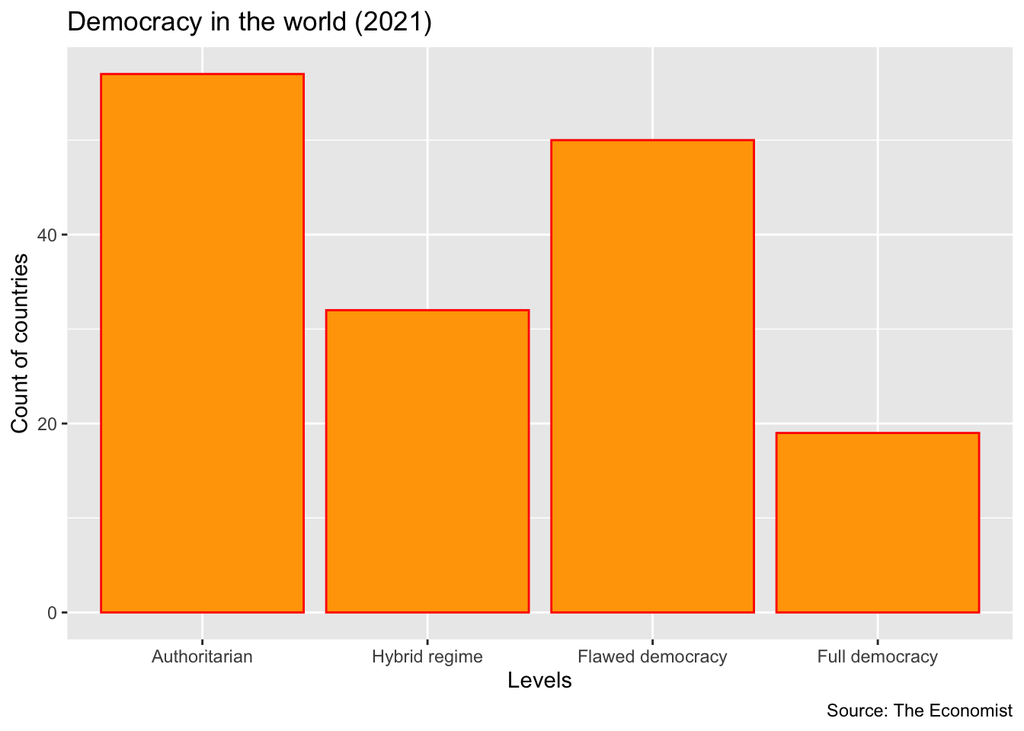

## 1.2 Exploring Numerical Data

Here, I continue doing this nice work, I hope you like it and read it. It has been a very hard work.Here, I continue doing this nice work, I hope you like it and read it. It has been a very hard work.Here, I continue doing this nice work, I hope you like it and read it. It has been a very hard work.Here, I continue doing this nice work, I hope you like it and read it. It has been a very hard work.Here, I continue doing this nice work, I hope you like it and read it. It has been a very hard work.Here, I continue doing this nice work, I hope you like it and read it. It has been a very hard work.Here, I continue doing this nice work, I hope you like it and read it. It has been a very hard work.Here, I continue doing this nice work, I hope you like it and read it. It has been a very hard work.Here, I continue doing this nice work, I hope you like it and read it. It has been a very hard work.

Here, I continue doing this nice work, I hope you like it and read it. It has been a very hard work.Here, I continue doing this nice work, I hope you like it and read it. It has been a very hard work.

Table 1.2: Stats summary for numeric vars

| Variable | N | Mean | Std. Dev. | Min | Pctl. 25 | Pctl. 75 | Max |
| --- | --- | --- | --- | --- | --- | --- | --- |
| HumanDevelopmentIndex | 158 | 0.7 | 0.2 | 0.4 | 0.6 | 0.8 | 1 |
| LifeExpectancyAtBirth | 158 | 71.2 | 7.9 | 52.5 | 65 | 76.8 | 85.5 |
| ExpectedYearsOfSchooling | 158 | 13.6 | 3 | 7 | 11.5 | 15.7 | 21.1 |
| MeanYearsOfSchooling | 158 | 9 | 3.3 | 2.1 | 6 | 11.6 | 14.1 |
| GrossNationalIncomePerCapita | 158 | 20126.6 | 20390 | 731.8 | 4552.4 | 30106 | 90918.6 |
| Overallscore | 158 | 5.3 | 2.3 | 0.3 | 3.2 | 7 | 9.8 |
| Electoralprocessandpluralism | 158 | 5.6 | 3.8 | 0 | 1.4 | 9.2 | 10 |
| Functioningofgovernment | 158 | 4.6 | 2.6 | 0 | 2.5 | 6.4 | 9.6 |
| Politicalparticipation | 158 | 5.4 | 2 | 0 | 3.9 | 6.7 | 10 |
| Politicalculture | 158 | 5.4 | 1.8 | 1.2 | 3.8 | 6.2 | 10 |
| Civilliberties | 158 | 5.4 | 2.7 | 0 | 3.2 | 7.7 | 9.7 |

In the Table 1.2, you see that the mean of HDI is **0.7201835**.

It would be good to see a boxplot with the re scaled values, check Figure 1.2 below.

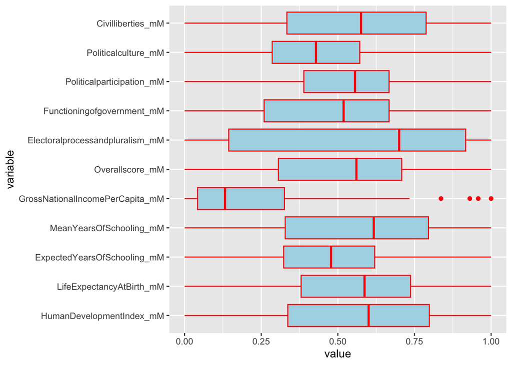

Figure 1.2: The nice boxplots

The boxplots you have just seen were introduced by (Tukey, 1977).

# 2 My Regression

Several times we need regression. This is a nice summary for two regressions, as shown in Table 2.1:

Table 2.1: Models for HDI

|  | Model 1 | Model 2 |
| --- | --- | --- |
| Constant | 0.526*** | 0.488*** |
|  | (0.018) | (0.026) |
| Bureaucracy | 0.042*** | 0.036*** |
|  | (0.003) | (0.005) |
| Participation |  | 0.013* |
|  |  | (0.006) |
| Num.Obs. | 158 | 158 |
| R2 | 0.489 | 0.502 |
| AIC | −238.8 | −240.8 |
| BIC | −229.6 | −228.6 |
| Log.Lik. | 122.396 | 124.419 |
| F | 149.539 | 78.226 |
| RMSE | 0.11 | 0.11 |

+ p < 0.1, * p < 0.05, ** p < 0.01, *** p < 0.001

I hope you like what you see in the Table 2.1. You can learn more on regression in other book (Petrie, 2016, pp. 150–160).

# 3 Other plots

## 3.1 A map

Let me show a nice map.Let me show a nice map.Let me show a nice map.Let me show a nice map.Let me show a nice map.Let me show a nice map.Let me show a nice map.Let me show a nice map.Let me show a nice map.Let me show a nice map.Let me show a nice map.Let me show a nice map.

Let me show a nice map.Let me show a nice map.Let me show a nice map.Let me show a nice map.Let me show a nice map.Let me show a nice map.Let me show a nice map.Let me show a nice map.Let me show a nice map.Let me show a nice map.Let me show a nice map.Let me show a nice map.

Let me show a nice map.Let me show a nice map.Let me show a nice map.Let me show a nice map.Let me show a nice map.Let me show a nice map.Let me show a nice map.Let me show a nice map.Let me show a nice map.Let me show a nice map.Let me show a nice map.Let me show a nice map in Figure 3.1.

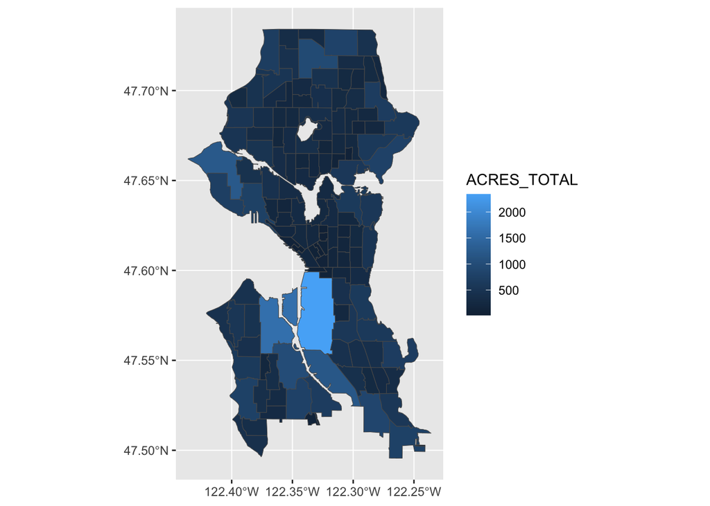

Figure 3.1: Plot numeric colums

Figure 3.1 uses only one layer. Let’s add another layer in the next map. Here, I continue doing this nice work, I hope you like it and read it. It has been a very hard work.Here, I continue doing this nice work, I hope you like it and read it. It has been a very hard work.Here, I continue doing this nice work, I hope you like it and read it. It has been a very hard work.Here, I continue doing this nice work, I hope you like it and read it.

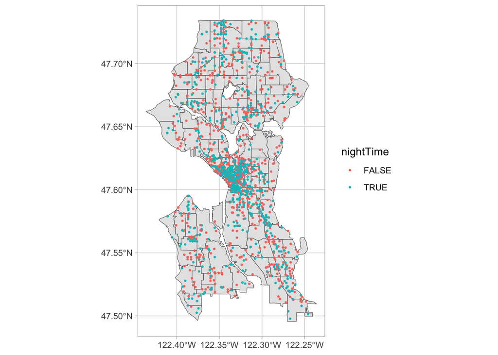

Figure 3.2: Calls to 911 by time of day

You can see that Figure 3.2 actually uses one map on top of the other. Let me show you an interactive version:

[interactive chart not shown]

Figure 3.3: A map using leaflet

Figure 3.3 above looks nice. Here, I continue doing this nice work, I hope you like it and read it. It has been a very hard work.Here, I continue doing this nice work, I hope you like it and read it. It has been a very hard work.Here, I continue doing this nice work, I hope you like it and read it. It has been a very hard work.Here, I continue doing this nice work, I hope you like it and read it.

Review other authors (Câmara et al., n.d., pp. 120–150; also, see Brunsdon & Comber, 2015) to know more.

# Bibliography

Brunsdon, C., & Comber, L. (2015). *An introduction to R for spatial analysis & mapping*. SAGE.

Câmara, G., Monteiro, A. M., Fucks, S. D., & Sá, M. (n.d.). *Spatial Analysis and GIS: A Primer*. 30.

Petrie, A. G. (2016). *Introduction to regression and modeling with R*.

Tukey, J. W. (1977). *Exploratory data analysis*. Addison-Wesley Pub. Co.

[^1]: This is a footnote.